# ExpandingReportingCapabilitiesCopy

## **Titanic Use Case**

|  | survived | pclass | sex | age | sibsp | parch | fare | embarked | class | who | adult_male | deck | embark_town | alive | alone |
| --- | --- | --- | --- | --- | --- | --- | --- | --- | --- | --- | --- | --- | --- | --- | --- |
| 0 | 0 | 3 | male | 22.0 | 1 | 0 | 7.2500 | S | Third | man | True | NaN | Southampton | no | False |
| 1 | 1 | 1 | female | 38.0 | 1 | 0 | 71.2833 | C | First | woman | False | C | Cherbourg | yes | False |
| 2 | 1 | 3 | female | 26.0 | 0 | 0 | 7.9250 | S | Third | woman | False | NaN | Southampton | yes | True |
| 3 | 1 | 1 | female | 35.0 | 1 | 0 | 53.1000 | S | First | woman | False | C | Southampton | yes | False |
| 4 | 0 | 3 | male | 35.0 | 0 | 0 | 8.0500 | S | Third | man | True | NaN | Southampton | no | True |

## How many adult males, adult females, and children embarked and how many of them survived?

| who | alive | 0 |
| --- | --- | --- |
| man | no | 449 |
| woman | yes | 205 |
| man | yes | 88 |
| woman | no | 66 |
| child | yes | 49 |
|  | no | 34 |

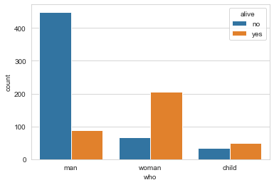

## What is the relationship for age and class?

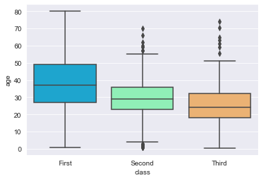

**We can observe that the first class is the class who had more senior individuals and we can observe that in lower classes individuals tend to be younger**

## Demographics based on town embarked from?

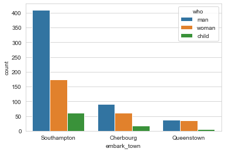

**Most of the people embarked from Southhampton,especially men. Possibily indicating that ship workers boarded in Southhampton**

## **Advertising Use Case**

The company is trying to decide whether to focus their efforts on their mobile app experience or their website. They need your exptertise to help them figure it out! Let's get started!

- **Avg. Session Length:** Average session of in-store style advice sessions.
- **Time on App:** Average time spent on App in minutes
- **Time on Website:** Average time spent on Website in minutes
- **Length of Membership:** How many years the customer has been a member

|  | Avg. Session Length | Time on App | Time on Website | Length of Membership | Yearly Amount Spent |
| --- | --- | --- | --- | --- | --- |
| count | 500.000000 | 500.000000 | 500.000000 | 500.000000 | 500.000000 |
| mean | 33.053194 | 12.052488 | 37.060445 | 3.533462 | 499.314038 |
| std | 0.992563 | 0.994216 | 1.010489 | 0.999278 | 79.314782 |
| min | 29.532429 | 8.508152 | 33.913847 | 0.269901 | 256.670582 |
| 25% | 32.341822 | 11.388153 | 36.349257 | 2.930450 | 445.038277 |
| 50% | 33.082008 | 11.983231 | 37.069367 | 3.533975 | 498.887875 |
| 75% | 33.711985 | 12.753850 | 37.716432 | 4.126502 | 549.313828 |
| max | 36.139662 | 15.126994 | 40.005182 | 6.922689 | 765.518462 |

## What is the most correlated feature?

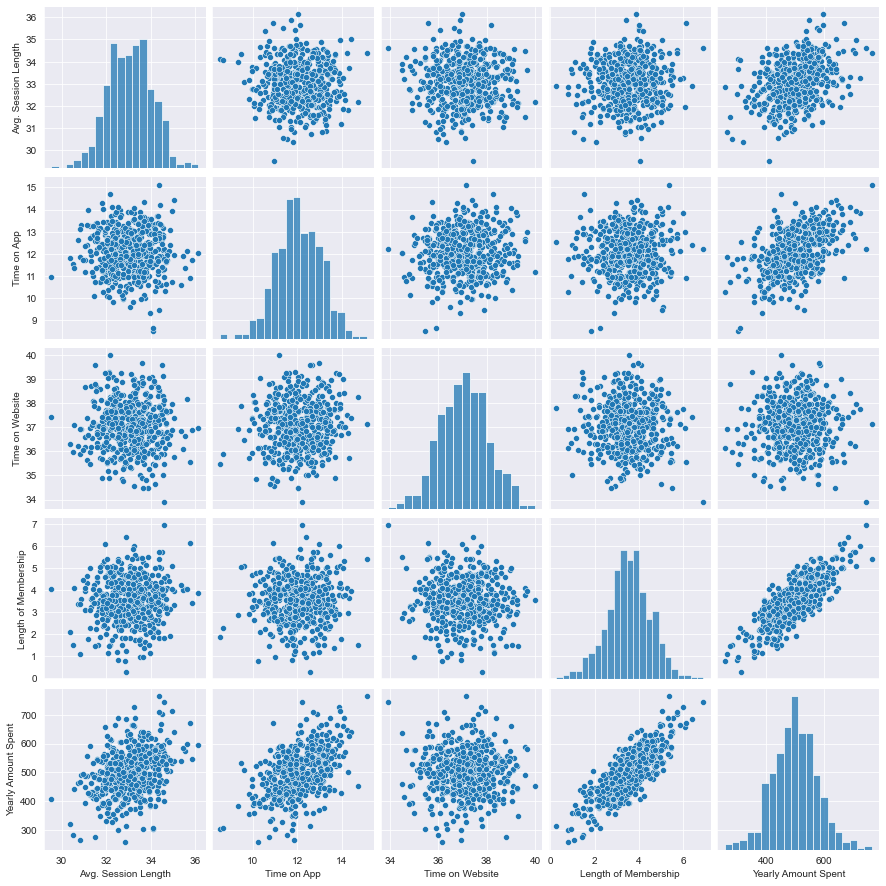

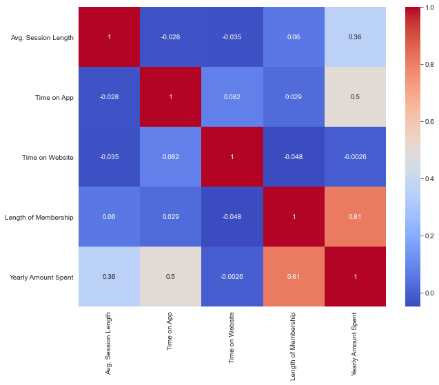

We can confirm that the Length of the Membership and Yearly Amount Spent are the most correlated features (positively) wih correlation coeficcient of 0.81

## So, where should the efforts based on the understanding of the features relationship?

**Let's use a linear regression analysis to understand how the company should allocate its efforts to improve the Yearly Amount Spent**

## Let's look at the predicted values and test values in a scatter plot

|  | y_test | predictions |
| --- | --- | --- |
| 18 | 452.315675 | 456.441861 |
| 361 | 401.033135 | 402.720053 |
| 104 | 410.069611 | 409.253154 |
| 4 | 599.406092 | 591.431034 |
| 156 | 586.155870 | 590.014373 |

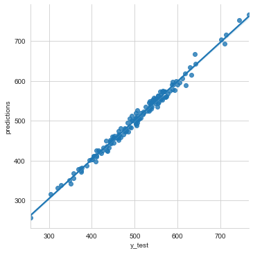

## Let's undertstand and visualize the residuals to evaluate the linear regression model

|  | Mean Absolute Error | Mean Square Error | Root Mean Square Error |
| --- | --- | --- | --- |
| 1 | 7.228149 | 79.813052 | 8.933815 |

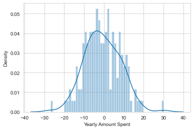

## Let's undertsand the coefficients

|  | Features | Coefficient Values |
| --- | --- | --- |
| 0 | Avg. Session Length | 25.981550 |
| 1 | Time on App | 38.590159 |
| 2 | Time on Website | 0.190405 |
| 3 | Length of Membership | 61.279097 |

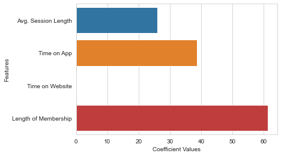

**Interpreting the coefficients:**

- Holding all other features fixed, a 1 unit increase in **Avg. Session Length** is associated with an **increase of 25.98 total dollars spent**.
- Holding all other features fixed, a 1 unit increase in **Time on App** is associated with an **increase of 38.59 total dollars spent**.
- Holding all other features fixed, a 1 unit increase in **Time on Website** is associated with an **increase of 0.19 total dollars spent**.
- Holding all other features fixed, a 1 unit increase in **Length of Membership** is associated with an **increase of 61.27 total dollars spent**.